[figure not shown]

| COMPONENTE CURRICULAR: | Propabilidade e Estatistica Aplicada |
| --- | --- |
| NOME COMPLETO DO ALUNO: | Nicolas Soares Santos |
| RA: | **10370082** |

## Exercícios

Lembrando aqui os exemplos empregados no inicío, sobre intervalos de confiança, para variância conhecida da população e não conhecida (uso de uma amostra).

```r
library(MASS)
head(survey)
```

```
##      Sex Wr.Hnd NW.Hnd W.Hnd    Fold Pulse    Clap Exer Smoke Height      M.I
## 1 Female   18.5   18.0 Right  R on L    92    Left Some Never 173.00   Metric
## 2   Male   19.5   20.5  Left  R on L   104    Left None Regul 177.80 Imperial
## 3   Male   18.0   13.3 Right  L on R    87 Neither None Occas     NA     <NA>
## 4   Male   18.8   18.9 Right  R on L    NA Neither None Never 160.00   Metric
## 5   Male   20.0   20.0 Right Neither    35   Right Some Never 165.00   Metric
## 6 Female   18.0   17.7 Right  L on R    64   Right Some Never 172.72 Imperial
##      Age
## 1 18.250
## 2 17.583
## 3 16.917
## 4 20.333
## 5 23.667
## 6 21.000
```

```r
mu = 5                                # Média da amostra, valor dado
sigma = 2                             # Desvio padrão conhecido da população
n = 20                                # Tamanho da amostra
stdm =  sigma/sqrt(n)                 # Desvio padrão da média da amostra (std mean)

error = qnorm(0.975)*stdm; error
```

```
## [1] 0.8765225
```

```r
xbar= c(mu - error, mu + error); xbar
```

```
## [1] 4.123477 5.876523
```

```r
mu = mean(survey$Height, na.rm=TRUE)  # Média da amostra
sigma = sd(survey$Height, na.rm=TRUE) # Desvio padrão da amostra
n = sum(!is.na(survey$Height))        # Tamanho da amostra
stdm =  sigma / sqrt(n)               # ESTIMATIVA do desvio padrão da média da amostra (std mean)

error = qt(0.975, df= n - 1 )*stdm; error
```

```
## [1] 1.342878
```

```r
xbar= c(mu - error, mu + error); xbar
```

```
## [1] 171.0380 173.7237
```

Para os testes de hipóteses vamos empregar o `t.test()` a menos de menção contrária.

### Exercício 1

Considere a base abaixo.

```r
head(ToothGrowth)
```

```
##    len supp dose
## 1  4.2   VC  0.5
## 2 11.5   VC  0.5
## 3  7.3   VC  0.5
## 4  5.8   VC  0.5
## 5  6.4   VC  0.5
## 6 10.0   VC  0.5
```

```r
# help(ToothGrowth)
```

1. Calcule o intervalo de confiança de `len`, de dados sobre crescimento dentário, para um nível de confiança de 95% (Você conhece a variância? acho que não :-) ).

```r
# Carregando a base de dados
data(ToothGrowth)

# Calcular a média e o desvio padrão da amostra
mu <- mean(ToothGrowth$len)
sigma <- sd(ToothGrowth$len)
n <- length(ToothGrowth$len)

# Calcular o erro padrão da média
stdm <- sigma / sqrt(n)

# Calcular o erro utilizando a distribuição t
error <- qt(0.975, df = n - 1) * stdm

# Calcular o intervalo de confiança
intervalo_confianca <- c(mu - error, mu + error)
intervalo_confianca
```

```
## [1] 16.83731 20.78936
```

2. Altere o nível de confiança para 98%. O resultado é o que você esperava? O que você observa, o intervalo é maior ou menor? (lembre-se de que você vai empregar uma distribuição bilateral)

```r
# Calcular o erro utilizando a distribuição t para 98% de confiança
error_98 <- qt(0.99, df = n - 1) * stdm

# Calcular o intervalo de confiança para 98%
intervalo_confianca_98 <- c(mu - error_98, mu + error_98)
intervalo_confianca_98
```

```
## [1] 16.45194 21.17473
```

O intervalo de confiança para 98% é um pouco mais amplo do que o intervalo para 95%, o que é esperado, já que estamos sendo mais conservadores ao aumentar o nível de confiança.

3. Para o mesmo problema gere um gráfico com os valores de E (o tamanho do intervalo /2/2) para os intervalos de nível de confiança de 50% a 99%. Qual o erro para 98%?

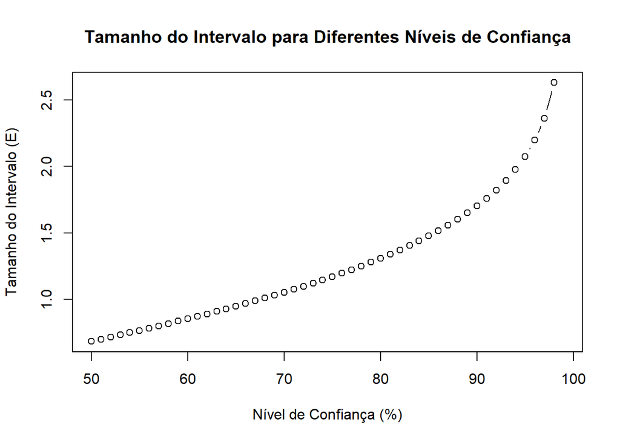

```r
# Criar vetor para armazenar os tamanhos dos intervalos
erros <- numeric(length = 50)

# Loop para calcular o erro para diferentes níveis de confiança
for (i in 1:50) {
  confianca <- 0.5 + i * 0.01
  erro_temp <- qt(confianca + (1 - confianca) / 2, df = n - 1) * stdm
  erros[i] <- erro_temp
}

# Plotar o gráfico
confiancas <- seq(50, 99, by = 1)
plot(confiancas, erros, type = "b",
     xlab = "Nível de Confiança (%)",
     ylab = "Tamanho do Intervalo (E)",
     main = "Tamanho do Intervalo para Diferentes Níveis de Confiança")
```

### Exercício 2

Considere a base de dados.

```r
bitcoin = read.csv('https://raw.githubusercontent.com/holtzy/data_to_viz/master/Example_dataset/3_TwoNumOrdered.csv',sep=' ',header=T)
head(bitcoin)
```

```
##         date  value
## 1 2013-04-28 135.98
## 2 2013-04-29 147.49
## 3 2013-04-30 146.93
## 4 2013-05-01 139.89
## 5 2013-05-02 125.60
## 6 2013-05-03 108.13
```

1. Considerando a série toda a histórica do valor do Bitcoin, qual o intervalo de confiança com nível de 95%? (vamos considerar que não conhecemos a variância, ela será mais conservadora).

```r
# Carregar os dados
bitcoin <- read.csv('https://raw.githubusercontent.com/holtzy/data_to_viz/master/Example_dataset/3_TwoNumOrdered.csv', sep=' ', header=TRUE)

# Criar o atributo "year"
bitcoin$year <- as.integer(format(as.Date(bitcoin$date), "%Y"))

# Calcular o intervalo de confiança para toda a série histórica
mu <- mean(bitcoin$value)
sigma <- sd(bitcoin$value)
n <- nrow(bitcoin)
stdm <- sigma / sqrt(n)
error <- qt(0.975, df = n - 1) * stdm
intervalo_confianca <- c(mu - error, mu + error)

# Exibir o intervalo de confiança
intervalo_confianca
```

```
## [1] 1636.697 1943.222
```

2. Crie um atributo `year` para as cotações de bitcoin. Empregue esse campo para auxiliá-lo para construir o gráfico a seguir. Para cada ano exiba em um gráfico o intervalo de confiança com nível de confiabilidade de 95% para cada ano.

**Dica**: Empregue e modifique os exercícios e exemplos anteriores. Selecione o ano `bitcoin[bitcoin$Year == ano ]$value`. Você também pode querer empregar `unique(bitcoin$year)`.

Que anos apresentam intervalos de confiança maiores?

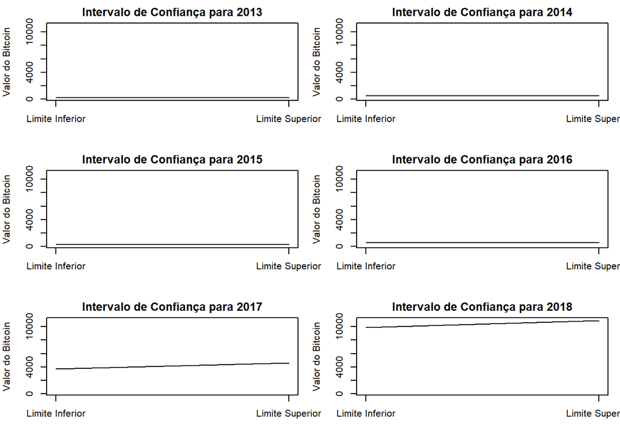

```r
# Calcular o intervalo de confiança para cada ano
anos <- unique(bitcoin$year)
intervalos_confianca <- list()

for (ano in anos) {
  bitcoin_ano <- subset(bitcoin, year == ano)
  mu_ano <- mean(bitcoin_ano$value)
  sigma_ano <- sd(bitcoin_ano$value)
  n_ano <- nrow(bitcoin_ano)
  stdm_ano <- sigma_ano / sqrt(n_ano)
  error_ano <- qt(0.975, df = n_ano - 1) * stdm_ano
  intervalos_confianca[[as.character(ano)]] <- c(mu_ano - error_ano, mu_ano + error_ano)
}

# Plotar o gráfico com margens menores
par(mfrow = c(ceiling(length(anos) / 2), 2), mar = c(4, 4, 2, 1))

for (i in 1:length(anos)) {
  ano <- anos[i]
  plot(intervalos_confianca[[as.character(ano)]], type = "l", ylim = range(intervalos_confianca),
       main = paste("Intervalo de Confiança para", ano),
       xlab = "", ylab = "Valor do Bitcoin", xaxt = "n")
  axis(1, at = c(1, 2), labels = c("Limite Inferior", "Limite Superior"))
}
```

### Exercício 3

Considere a base.

```r
head(USArrests)
```

```
##            Murder Assault UrbanPop Rape
## Alabama      13.2     236       58 21.2
## Alaska       10.0     263       48 44.5
## Arizona       8.1     294       80 31.0
## Arkansas      8.8     190       50 19.5
## California    9.0     276       91 40.6
## Colorado      7.9     204       78 38.7
```

1. Compare o intervalo de confiança de média de assassinatos dos estados com população urbana acima > 50% e abaixo de <= 50%. Empregue um nível de confiabilidade de 95%. Quais os valores obtidos?

Será que você pode garantir que os valores são de fato diferentes? (aplique um `t.test`)

```r
# Separando os dados em dois grupos: população urbana acima de 50% e abaixo ou igual a 50%
urban_high <- USArrests[USArrests$UrbanPop > 50, "Murder"]
urban_low <- USArrests[USArrests$UrbanPop <= 50, "Murder"]

# Calculando os intervalos de confiança para cada grupo
conf_int_high <- t.test(urban_high)$conf.int
conf_int_low <- t.test(urban_low)$conf.int

# Apresentando os intervalos de confiança
print("Intervalo de Confiança para População Urbana acima de 50%:")
```

```
## [1] "Intervalo de Confiança para População Urbana acima de 50%:"
```

```r
print(conf_int_high)
```

```
## [1] 6.369081 8.977261
## attr(,"conf.level")
## [1] 0.95
```

```r
print("Intervalo de Confiança para População Urbana abaixo ou igual a 50%:")
```

```
## [1] "Intervalo de Confiança para População Urbana abaixo ou igual a 50%:"
```

```r
print(conf_int_low)
```

```
## [1]  4.068188 12.554034
## attr(,"conf.level")
## [1] 0.95
```

```r
# Realizando o teste t para comparar as médias dos dois grupos
t_test_result <- t.test(urban_high, urban_low)
print("Resultado do Teste t:")
```

```
## [1] "Resultado do Teste t:"
```

```r
print(t_test_result)
```

```
##
##  Welch Two Sample t-test
##
## data:  urban_high and urban_low
## t = -0.32718, df = 10.058, p-value = 0.7502
## alternative hypothesis: true difference in means is not equal to 0
## 95 percent confidence interval:
##  -4.978969  3.703088
## sample estimates:
## mean of x mean of y
##  7.673171  8.311111
```

### Exercício 4

1. Qual o valor de t e de p-value para duas amostras de distribuição normal idênticas?

**Dica**: Empregue o `rnorm()` para gerar as amostras e o `t.test()` para obter os valores.

```r
# Gerando duas amostras de distribuição normal idênticas
x <- rnorm(25)
y <- rnorm(25)

# Realizando o teste t
result <- t.test(x, y)
print("Valor de t:")
```

```
## [1] "Valor de t:"
```

```r
print(result$statistic)
```

```
##         t
## -1.385589
```

```r
print("Valor de p-value:")
```

```
## [1] "Valor de p-value:"
```

```r
print(result$p.value)
```

```
## [1] 0.1722792
```

2. Considere agora as amostras:

```r
x = rnorm(25, mean = 100, sd = 10);
y = rnorm(25, mean = 101, sd = 10)
```

Elas têm médias iguais na maior ou na menor parte das vezes?

**Dica** Gere 100 experimentos (amostras diferentes de x e y) e verifique o p-value do `t.test` e produza um gráfico ou algo semelhante para observar a proporção de valores dos p-values.

```r
p = c(0)
for (i in 1:100){
  x = rnorm(25, mean = 100, sd = 10); # x
  y = rnorm(25, mean = 101, sd = 10); # y
  result = t.test(x,y)
  # names(result)
  if (result$p.value < 0.05) print(result$p.value)
  p[i] = result$p.value
}
```

```
## [1] 0.03216958
## [1] 0.03820283
## [1] 0.001720906
## [1] 0.02842249
## [1] 0.01475249
## [1] 0.01221674
## [1] 0.02810892
## [1] 0.001048263
## [1] 0.01117365
## [1] 0.04350517
```

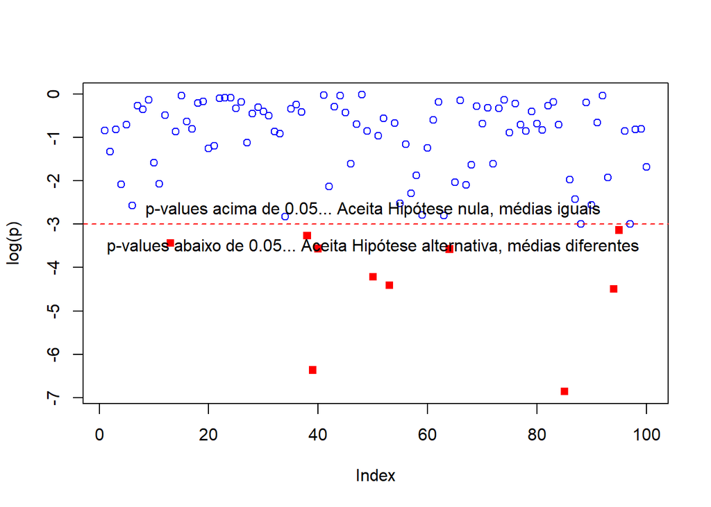

```r
plot(log(p),col='blue')
for (i in 1:100){
  if (p[i] < 0.05) lines(i,log(p[i]),pch=15,type='b',col='red')
}
abline(h=log(0.05),col='red',lty=2)
text(50,log(0.07),'p-values acima de 0.05... Aceita Hipótese nula, médias iguais')
text(50,log(0.03),'p-values abaixo de 0.05... Aceita Hipótese alternativa, médias diferentes')
```

3. Considere agora as amostras:

```r
x = rnorm(25, mean = 100, sd = 2.5);
y = rnorm(25, mean = 101, sd = 2.5)
```

O fato de diminuírmos o desvio padrão aumenta a chance dos dados terem média significativamente iguais ou diferentes?

```r
# Definir as amostras
x <- rnorm(25, mean = 100, sd = 2.5)
y <- rnorm(25, mean = 100, sd = 2.5)

# Calcular o valor de t e o p-value
result <- t.test(x, y)
t_value <- result$statistic
p_value <- result$p.value

# Exibir os resultados
print(paste("Valor de t:", t_value))
```

```
## [1] "Valor de t: 0.55376473037204"
```

```r
print(paste("Valor de p-value:", p_value))
```

```
## [1] "Valor de p-value: 0.582321060620267"
```

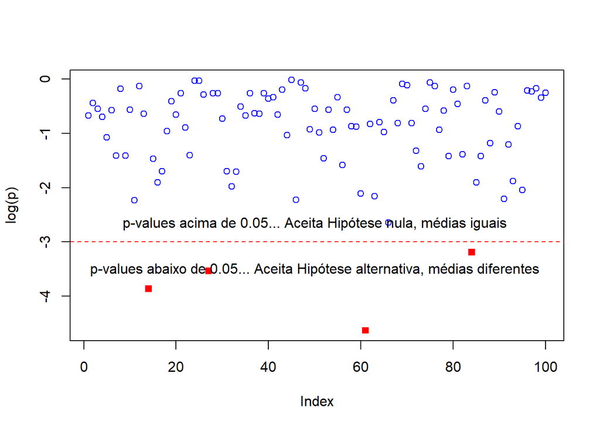

```r
# Repetir o processo 100 vezes
p <- c()
for (i in 1:100) {
  x <- rnorm(25, mean = 100, sd = 2.5)
  y <- rnorm(25, mean = 100, sd = 2.5)
  result <- t.test(x, y)
  p[i] <- result$p.value
}

# Plotar um gráfico para observar a proporção de valores de p-value abaixo de 0.05
plot(log(p), col = 'blue')
for (i in 1:100) {
  if (p[i] < 0.05) lines(i, log(p[i]), pch = 15, type = 'b', col = 'red')
}
abline(h = log(0.05), col = 'red', lty = 2)
text(50, log(0.07), 'p-values acima de 0.05... Aceita Hipótese nula, médias iguais')
text(50, log(0.03), 'p-values abaixo de 0.05... Aceita Hipótese alternativa, médias diferentes')
```

### Exercício 5

Você recebe 25 amostras de embalagens de frutas especificadas como embalagens de 100g. Seus pesos são:

```r
set.seed(1234)
x = rnorm(25, mean = 100, sd = 12); x
```

```
##  [1]  85.51521 103.32915 113.01329  71.85163 105.14950 106.07267  93.10312
##  [8]  93.44042  93.22658  89.31955  94.27369  88.01936  90.68495 100.77351
## [15] 111.51393  98.67657  93.86789  89.06566  89.95394 128.99002 101.60906
## [22]  94.11177  94.71343 105.51507  91.67536
```

```r
mean(x)
```

```
## [1] 97.09861
```

As amostras mostram um valor de média menor que 100g. O produto ainda assim está dentro da especificação (dentro de uma significância de 95%)?

```r
# Definir as amostras
set.seed(1234)
x <- rnorm(25, mean = 100, sd = 12)

# Calcular a média das amostras
media_amostras <- mean(x)

# Realizar o teste t de uma amostra
resultado_teste <- t.test(x, mu = 100)

# Obter o valor do p-value
p_value <- resultado_teste$p.value

# Verificar se o produto está dentro da especificação
if (p_value > 0.05) {
  print("O produto está dentro da especificação com uma significância de 95%.")
} else {
  print("O produto está fora da especificação com uma significância de 95%.")
}
```

```
## [1] "O produto está dentro da especificação com uma significância de 95%."
```

```r
# Exibir o valor de média das amostras
print(paste("Média das amostras:", media_amostras))
```

```
## [1] "Média das amostras: 97.0986123842831"
```

### Exercício 6

Considere a base de remunareções (*wage*) abaixo.

```r
data(CPS85 , package = "mosaicData")
head(CPS85)
```

```
##   wage educ race sex hispanic south married exper union age   sector
## 1  9.0   10    W   M       NH    NS Married    27   Not  43    const
## 2  5.5   12    W   M       NH    NS Married    20   Not  38    sales
## 3  3.8   12    W   F       NH    NS  Single     4   Not  22    sales
## 4 10.5   12    W   F       NH    NS Married    29   Not  47 clerical
## 5 15.0   12    W   M       NH    NS Married    40 Union  58    const
## 6  9.0   16    W   F       NH    NS Married    27   Not  49 clerical
```

1. Faça o `boxplot` da remuneração de homens e mulheres e observe as distribuições. Empregue o teste de hipóteses para responder se os ganhos (`wage`) de homens e mulheres é significativamente diferente.

**Dica** Empregue o `t.test()`.

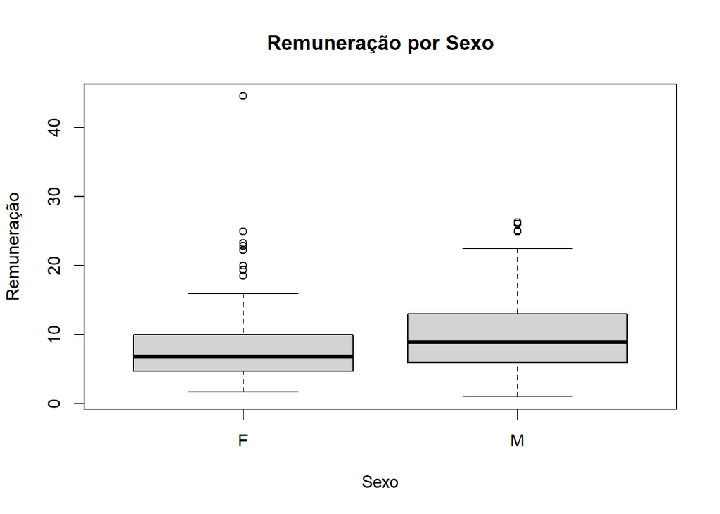

```r
# Carregar o pacote mosaicData para acessar os dados CPS85
library(mosaicData)

# Carregar os dados CPS85
data(CPS85)

# Boxplot da remuneração de homens e mulheres
boxplot(wage ~ sex, data = CPS85, xlab = "Sexo", ylab = "Remuneração", main = "Remuneração por Sexo")
```

```r
# Importar os dados para variáveis separadas para homens e mulheres
wage_homens <- CPS85$wage[CPS85$sex == "M"]
wage_mulheres <- CPS85$wage[CPS85$sex == "F"]

# Realizar o teste t para verificar se os ganhos de homens e mulheres são significativamente diferentes
resultado_teste <- t.test(wage_homens, wage_mulheres)

# Obter o valor do p-value
p_value <- resultado_teste$p.value

# Verificar se os ganhos de homens e mulheres são significativamente diferentes
if (p_value > 0.05) {
  print("Os ganhos de homens e mulheres não são significativamente diferentes.")
} else {
  print("Os ganhos de homens e mulheres são significativamente diferentes.")
}
```

```
## [1] "Os ganhos de homens e mulheres são significativamente diferentes."
```

2. Empregue o teste de hipóteses para responder se os ganhos (`wage`) de casados é significativamente maior que dos solteiros.

**Dica** Empregue o `t.test()`. Note que aqui o teste é unilateral.

```r
# Importar os dados para variáveis separadas para casados e solteiros
wage_casados <- CPS85$wage[CPS85$married == "Married"]
wage_solteiros <- CPS85$wage[CPS85$married == "Single"]

# Realizar o teste t para verificar se os ganhos de casados são significativamente maiores que dos solteiros
resultado_teste_casados <- t.test(wage_casados, mu = mean(wage_solteiros), alternative = "greater")

# Obter o valor do p-value
p_value_casados <- resultado_teste_casados$p.value

# Verificar se os ganhos de casados são significativamente maiores que dos solteiros
if (p_value_casados > 0.05) {
  print("Os ganhos de casados não são significativamente maiores que dos solteiros.")
} else {
  print("Os ganhos de casados são significativamente maiores que dos solteiros.")
}
```

```
## [1] "Os ganhos de casados são significativamente maiores que dos solteiros."
```

### Exercício 7

Considere a base de salários deste ano (abaixo). O Salário médio da empresa no ano passado foi de 96.000 (atributo `income`). A empresa fez uma série de ações no campo da remuneração para reduzir custos este ano (base atual) e tornar-se mais competitiva. Essas ações tiveram um efeito significativo? Isto é, o salário é significativamente menor? (significância de 0.05)

```r
data = read.csv('http://meusite.mackenzie.br/rogerio/TIC/Projects/glassdoordata.csv')
head(data)
```

```
##              jobtitle gender age performance education     department seniority
## 1    Graphic Designer Female  18           5   College     Operations         2
## 2   Software Engineer   Male  21           5   College     Management         5
## 3 Warehouse Associate Female  19           4       PhD Administration         5
## 4   Software Engineer   Male  20           5   Masters          Sales         4
## 5    Graphic Designer   Male  26           5   Masters    Engineering         5
## 6                  IT Female  20           5       PhD     Operations         4
##   income bonus
## 1  42363  9938
## 2 108476 11128
## 3  90208  9268
## 4 108080 10154
## 5  99464  9319
## 6  70890 10126
```

```r
# Carregar os dados
data <- read.csv('http://meusite.mackenzie.br/rogerio/TIC/Projects/glassdoordata.csv')

# Calcular a média dos salários deste ano
mean_salary_this_year <- mean(data$income)

# Definir a média do ano passado
mean_salary_last_year <- 96000

# Realizar o teste de hipóteses
result <- t.test(data$income, mu = mean_salary_last_year, alternative = "less")

# Obter o valor-p
p_value <- result$p.value

# Comparar o valor-p com o nível de significância
alpha <- 0.05

if (p_value < alpha) {
  print("O salário deste ano é significativamente menor que o salário do ano passado.")
} else {
  print("Não há evidências suficientes para afirmar que o salário deste ano é significativamente menor que o salário do ano passado.")
}
```

```
## [1] "O salário deste ano é significativamente menor que o salário do ano passado."
```

### Exercício 8

1. Considere o preço de imóveis de Melbourne da base abaixo. Você quer vender um imóvel em Melbourne e acredita que vendas do tipo (atributo `Method`) ‘PI’ (‘passed in’) - digamos, com o uso de um intermediador - não tem qualquer vantagem sobre o método ‘S’ (‘sold’) - digamos, venda direta - em termos de preço e que, portanto você estaria perdendo tempo e dinheiro buscando a venda por um intermediário (digamos, corretor). Você estaria correto? Avalie com um teste de hipótese de significância 0.05.

**Dica** Antes de fazer o teste, pense se perder dinheiro é bilateral o unilateral.

```r
houses = read.csv('https://meusite.mackenzie.br/rogerio/TIC/Melbourne_housing_FULL.csv')
head(houses)
```

```
##       Suburb            Address Rooms Type   Price Method SellerG      Date
## 1 Abbotsford      68 Studley St     2    h      NA     SS  Jellis 3/09/2016
## 2 Abbotsford       85 Turner St     2    h 1480000      S  Biggin 3/12/2016
## 3 Abbotsford    25 Bloomburg St     2    h 1035000      S  Biggin 4/02/2016
## 4 Abbotsford 18/659 Victoria St     3    u      NA     VB  Rounds 4/02/2016
## 5 Abbotsford       5 Charles St     3    h 1465000     SP  Biggin 4/03/2017
## 6 Abbotsford   40 Federation La     3    h  850000     PI  Biggin 4/03/2017
##   Distance Postcode Bedroom2 Bathroom Car Landsize BuildingArea YearBuilt
## 1      2.5     3067        2        1   1      126           NA        NA
## 2      2.5     3067        2        1   1      202           NA        NA
## 3      2.5     3067        2        1   0      156           79      1900
## 4      2.5     3067        3        2   1        0           NA        NA
## 5      2.5     3067        3        2   0      134          150      1900
## 6      2.5     3067        3        2   1       94           NA        NA
##          CouncilArea Lattitude Longtitude            Regionname Propertycount
## 1 Yarra City Council  -37.8014   144.9958 Northern Metropolitan          4019
## 2 Yarra City Council  -37.7996   144.9984 Northern Metropolitan          4019
## 3 Yarra City Council  -37.8079   144.9934 Northern Metropolitan          4019
## 4 Yarra City Council  -37.8114   145.0116 Northern Metropolitan          4019
## 5 Yarra City Council  -37.8093   144.9944 Northern Metropolitan          4019
## 6 Yarra City Council  -37.7969   144.9969 Northern Metropolitan          4019
```

```r
# Carregar os dados
houses <- read.csv('https://meusite.mackenzie.br/rogerio/TIC/Melbourne_housing_FULL.csv')

# Filtrar apenas as vendas do tipo "PI" e "S"
sales_PI <- houses[houses$Method == "PI", "Price"]
sales_S <- houses[houses$Method == "S", "Price"]

# Realizar o teste de hipóteses
result <- t.test(sales_PI, sales_S, alternative = "less")

# Obter o valor-p
p_value <- result$p.value

# Comparar o valor-p com o nível de significância
alpha <- 0.05

if (p_value < alpha) {
  print("Há evidências estatísticas para afirmar que as vendas do tipo 'PI' têm preços significativamente menores do que as vendas do tipo 'S'.")
} else {
  print("Não há evidências estatísticas para afirmar que as vendas do tipo 'PI' têm preços significativamente menores do que as vendas do tipo 'S'.")
}
```

```
## [1] "Não há evidências estatísticas para afirmar que as vendas do tipo 'PI' têm preços significativamente menores do que as vendas do tipo 'S'."
```

2. A função `t.test()` apresenta uma forma de automaticamente separar dois (apenas dois!) conjuntos de valores em um dataframe empregando a fórmula:

```
Atributo_test ~ Atributo_grupo
```

Procure no help do comando `t.test` e aplique ao exercício anterior.